# Introduction to Machine Learning 2

September 23, 2015

## Recap

- character
- numerical
- logical
- factor

All 1-D vectors

## Dataframe

```r
df <- data.frame(a = c(1,2,3), b = c("A","B","C"))
names(df)[2] <- "River/Creek"
df$a
```

```
## [1] 1 2 3
```

```r
df$"River/Creek"
```

```
## [1] A B C
## Levels: A B C
```

This is ugly.. Sugget only use ".", "_" in variable names

## Basic ML Procedure

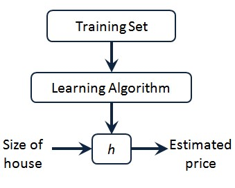

## Who's model rank supreme?

## Who's model rank supreme?

My score is:

```r
summary(g)$adj.r.squared
```

```
## [1] 0.6423735
```

But wait a second, is adj.r.squared really a good metric?

Or in other word, is adj.r.squared really the cost we care to minimizing?

## Linear Regression Model (A Family of models, H)

- Independent variable expressed as a linear combination of dependent varibales
- \(y = w_0 + w_1x_1 + ... + w_kx_k\)
- let \(x_0 = 1\) and rewrite the above formula
- \(y = w_0x_0 + w_1x_1 + ... + w_kx_k\)
- that is \({\bf y} = {\bf w}^T{\bf x}\)
- different \({\bf w} \implies\) different model(h) in the family(\(H\))

## How to determine good model or bad model?

- Commonly, want a model(h) that minimizes RSS of insample predictions
- \(RSS = \Sigma{(y^{(i)} - \hat{y^{(i)}})^2}\)
- where \(\hat{y^{(i)}} = {\bf w}^T{x^{(i)}}\)
- So the problem, stated in optimization term is:
- \[\min_{{\bf w}} RSS = \Sigma{(y^{(i)} - {\bf w}^T{x^{(i)}})^2}\\ s.t. nothing \qquad really...\]

## Stats, OR, ML

- Stats Model  
  Minimizing math cost function w.r.t math constraints  
  Obtain mathmatical properties  
  Hope to be useful in business context
- OR Model  
  Minimizing business cost function w.r.t business constraints  
  Useful in business context  
  Hope model is stable/ robust
- Machine Learning  
  Build lots of math models  
  Select the one according business requirements  
  Two stages of optimization
- Analytic = Decision Making

## Basic ML Procedure

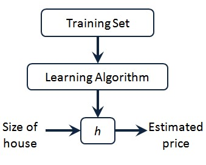

## Basic ML Procedure

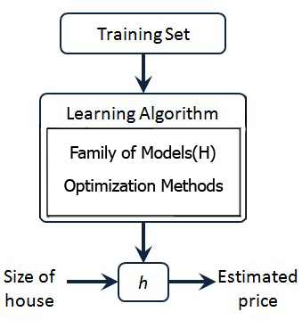

## ML Procedure

with model selection based on validation set

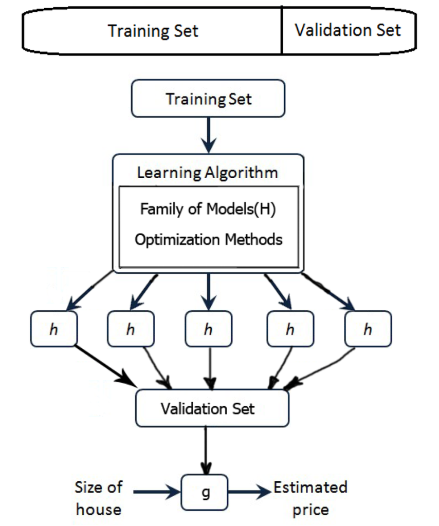

## Matrix

## Normal Equation

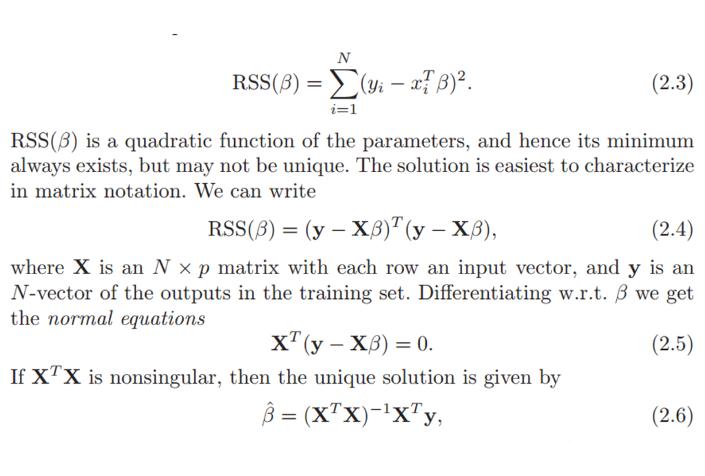

## Normal Equation

```r
houseData <- read.csv("Data.csv")
X = as.matrix(cbind(rep(1,nrow(houseData)),houseData[,3:5]))
Y = as.matrix(houseData$Price)
beta = solve(t(X) %*% X) %*% (t(X) %*% Y)
t(beta)
```

```
##      rep(1, nrow(houseData))  Sq.Feet      Beds    Baths
## [1,]                301459.2 96.91435 -2762.526 8487.688
```

```r
lm(Price~Sq.Feet+Beds+Baths, houseData)$coefficients
```

```
##  (Intercept)      Sq.Feet         Beds        Baths
## 301459.21171     96.91435  -2762.52577   8487.68849
```

## Function

```r
myMean <- function(data) sum(data)/length(data)
myMean(rnorm(999,10,1.2))
```

```
## [1] 10.00658
```

```r
myMean2 <- function(data){
  s = sum(data)
  n = length(data)
  m = s/n
  return(m)
}
myMean2(seq(100,200,2))
```

```
## [1] 150
```

## Why Function

- easier for debugging
- define - test - use without worring about the detail any longer

```r
readData <- function{...}
parseData <- function(...)
generateFeature <- function(...)
trainModel <- function(...)
validationModel <- function(...)
makePrediction <- function(...)

df <- generateFeature(parseData(readData(...)))
model <- trainModel(df)
etc...
```